# chapter6.Rmd

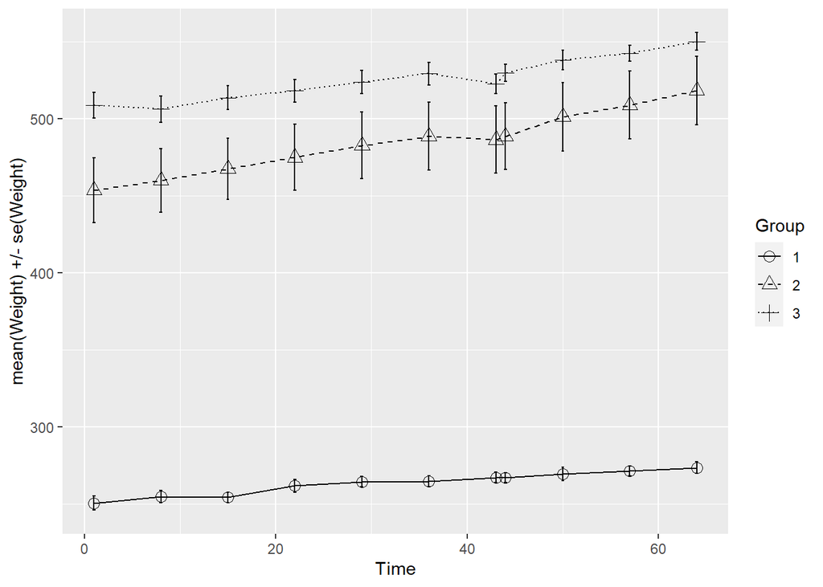

```r
ggplot(RaSu, aes(x = Time, y = mean, linetype = Group, shape = Group)) + geom_line() + scale_linetype_manual(values = c(1,2,3)) + geom_point(size=3) + scale_shape_manual(values = c(1,2,3)) + geom_errorbar(aes(ymin = mean - se, ymax = mean + se, linetype="1"), width=0.3) + scale_y_continuous(name = "mean(Weight) +/- se(Weight)")
```

```r
library(dplyr)
library(tidyr)
RaSuT <- RATSL %>% filter(Time > 0) %>% group_by(Group,ID) %>% summarise( mean=mean(Weight) ) %>% ungroup()
glimpse(RaSuT)
```

```
## Rows: 16
## Columns: 3
## $ Group <fct> 1, 1, 1, 1, 1, 1, 1, 1, 2, 2, 2, 2, 3, 3, 3, 3
## $ ID    <fct> 1, 2, 3, 4, 5, 6, 7, 8, 9, 10, 11, 12, 13, 14, 15, 16
## $ mean  <dbl> 261.0909, 237.6364, 260.1818, 266.5455, 269.4545, 274.7273, 2...
```

Looking for outliers without baseline (day 1)

```r
library(dplyr)
library(tidyr)
Rxx <- RATSL %>% filter(Time > 1) %>% group_by(Group,ID) %>% summarise( mean=mean(Weight) ) %>% ungroup()
glimpse(Rxx)
```

```
## Rows: 16
## Columns: 3
## $ Group <fct> 1, 1, 1, 1, 1, 1, 1, 1, 2, 2, 2, 2, 3, 3, 3, 3
## $ ID    <fct> 1, 2, 3, 4, 5, 6, 7, 8, 9, 10, 11, 12, 13, 14, 15, 16
## $ mean  <dbl> 263.2, 238.9, 261.7, 267.2, 270.9, 276.2, 274.6, 267.5, 443.9...
```

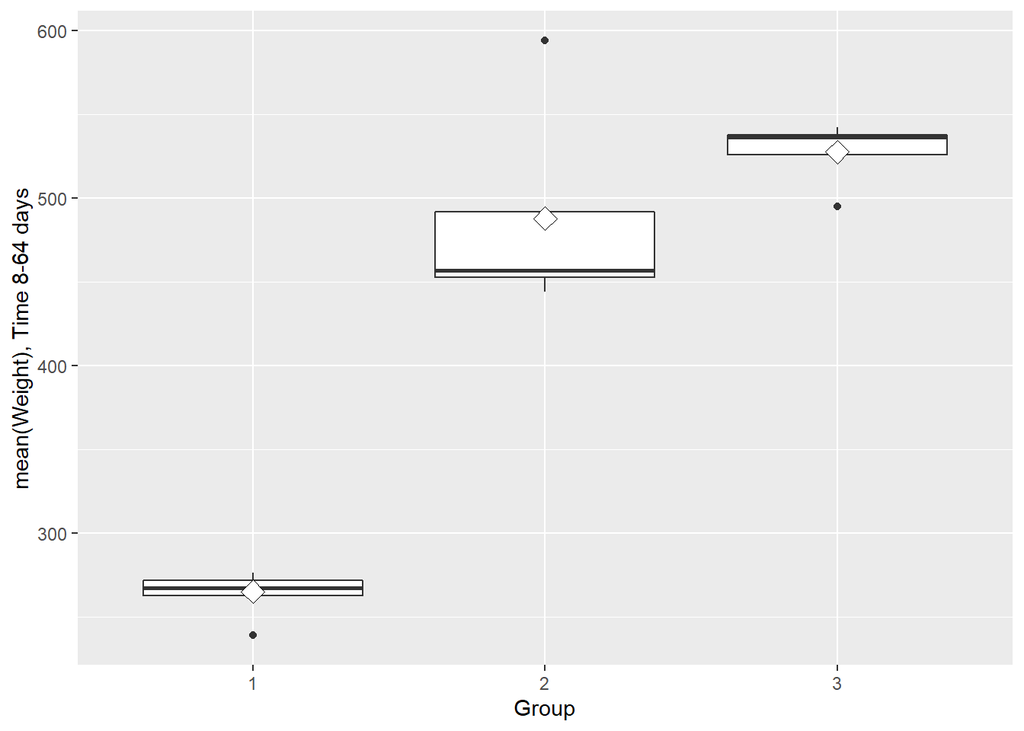

```r
ggplot(Rxx, aes(x = Group, y = mean)) + geom_boxplot() + stat_summary(fun.y = "mean", geom = "point", shape=23, size=4, fill = "white") + scale_y_continuous(name = "mean(Weight), Time 8-64 days")
```

Seems that there are smaller outliers in groups 1 and 3, yet, in group 2 there is quite obvious outlier.

Filtering outliers

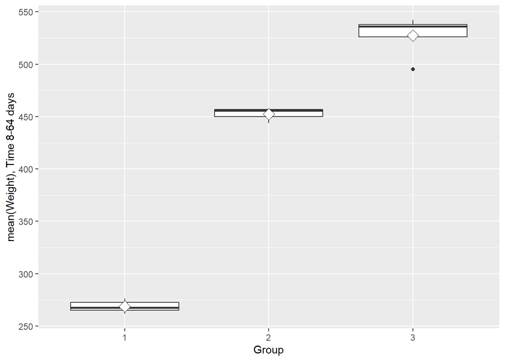

```r
RaSuTX <- Rxx %>% filter(mean < 550, mean > 250)
ggplot(RaSuTX, aes(x = Group, y = mean)) + geom_boxplot() + stat_summary(fun.y = "mean", geom = "point", shape=23, size=4, fill = "white") + scale_y_continuous(name = "mean(Weight), Time 8-64 days")
```

Now there is clearly a difference in group 2 boxplot. At this point group 3 outlier proved to be too difficult to exclude. Any tips to get it excluded?

Tests for differences

T-test, not possible because grouping factor has >2 levels. t.test(mean ~ Group, data = RaSuTX, var.equal = TRUE)

Anova (SEE before, RaSuT data has baseline with it).

```r
fit <- lm(mean ~ Group, data = RaSuT)
anova(fit)
```

```
## Analysis of Variance Table
##
## Response: mean
##           Df Sum Sq Mean Sq F value    Pr(>F)
## Group      2 236732  118366  88.073 2.763e-08 ***
## Residuals 13  17471    1344
## ---
## Signif. codes:  0 '***' 0.001 '**' 0.01 '*' 0.05 '.' 0.1 ' ' 1
```

Since P is very small the groups are different.